# R Notebook

# Importing the data

Read the raw counts using code from previous session

```r
library(tximport)
library(DESeq2)
dirs <- list.files(file.path("salmon_quant/"))
quant_files <- paste0("salmon_quant/",dirs,"/quant.sf.gz")
names(quant_files) <- dirs

tx2gene <- read.csv("tx2gene.csv")

txi <- tximport(quant_files,type="salmon",tx2gene = tx2gene)
```

```
reading in files with read_tsv
1 2 3 4 5 6 7 8 9
transcripts missing from tx2gene: 1
summarizing abundance
summarizing counts
summarizing length
```

```r
sampleinfo <- read.delim("meta_data/sampleInfo_corrected.txt")
rownames(sampleinfo) <- sampleinfo$run

dds <- DESeqDataSetFromTximport(txi,
                                colData = sampleinfo,
                                design = ~condition)
```

# Exercise

We now want to use the `condition` as our factor of interest. This can be achieved by changing the `design` our object

```r
dds_condition<- dds
design(dds_condition) <- ~condition
```

```r
results(de_condition)
```

```
log2 fold change (MLE): condition TGF vs CTR
Wald test p-value: condition TGF vs CTR
DataFrame with 57914 rows and 6 columns
                   baseMean log2FoldChange
                  <numeric>      <numeric>
ENSG00000000003 1447.265802      -0.233372
ENSG00000000005    0.113575      -0.104328
ENSG00000000419 1814.108471      -0.147784
ENSG00000000457  645.735472      -0.204533
ENSG00000000460  221.065743       0.064595
...                     ...            ...
ENSG00000284744    8.377622      -0.217574
ENSG00000284745    0.000000             NA
ENSG00000284746    0.102422      -1.066085
ENSG00000284747   29.068925      -0.294968
ENSG00000284748    0.548454       0.857795
                    lfcSE       stat    pvalue
                <numeric>  <numeric> <numeric>
ENSG00000000003  0.124128 -1.8800995 0.0600945
ENSG00000000005  4.080456 -0.0255678 0.9796020
ENSG00000000419  0.142725 -1.0354479 0.3004598
ENSG00000000457  0.131904 -1.5506201 0.1209927
ENSG00000000460  0.262747  0.2458452 0.8058021
...                   ...        ...       ...
ENSG00000284744  0.826403  -0.263278  0.792336
ENSG00000284745        NA         NA        NA
ENSG00000284746  4.080456  -0.261266  0.793887
ENSG00000284747  0.476711  -0.618757  0.536077
ENSG00000284748  4.080456   0.210220  0.833496
                     padj
                <numeric>
ENSG00000000003  0.235475
ENSG00000000005        NA
ENSG00000000419  0.593524
ENSG00000000457  0.356656
ENSG00000000460  0.928951
...                   ...
ENSG00000284744        NA
ENSG00000284745        NA
ENSG00000284746        NA
ENSG00000284747  0.779801
ENSG00000284748        NA
```

The default contrast is already TGF vs CTRL. As above we can create a data frame for further processing.

```r
results(de_condition, tidy = TRUE)
```

| row | baseMean | log2FoldChange | lfcSE | stat | pvalue | padj |
| --- | --- | --- | --- | --- | --- | --- |
| ENSG00000000003 | 1.447266e+03 | -0.233372156 | 0.12412756 | -1.880099495 | 6.009452e-02 | 2.354750e-01 |
| ENSG00000000005 | 1.135747e-01 | -0.104328474 | 4.08045587 | -0.025567848 | 9.796020e-01 | NA |
| ENSG00000000419 | 1.814108e+03 | -0.147784307 | 0.14272501 | -1.035447857 | 3.004598e-01 | 5.935242e-01 |
| ENSG00000000457 | 6.457355e+02 | -0.204533311 | 0.13190420 | -1.550620123 | 1.209927e-01 | 3.566563e-01 |
| ENSG00000000460 | 2.210657e+02 | 0.064595002 | 0.26274669 | 0.245845163 | 8.058021e-01 | 9.289514e-01 |
| ENSG00000000938 | 7.645304e+00 | -2.024521441 | 1.03765949 | -1.951046042 | 5.105157e-02 | NA |
| ENSG00000000971 | 5.393851e+03 | -0.457327422 | 0.10932429 | -4.183218750 | 2.874106e-05 | 6.266822e-04 |
| ENSG00000001036 | 3.649162e+03 | -0.369758129 | 0.08820950 | -4.191817736 | 2.767283e-05 | 6.069228e-04 |
| ENSG00000001084 | 9.416370e+02 | -0.285383157 | 0.18447267 | -1.547021331 | 1.218581e-01 | 3.579677e-01 |
| ENSG00000001167 | 1.276092e+03 | 0.117625706 | 0.11085315 | 1.061094799 | 2.886468e-01 | 5.806417e-01 |

[output cut: 990 more lines]

We can filter to discover differentially-expressed genes and write out to a file

```r
library(readr)
results(de_condition, tidy=TRUE) %>%
  filter(abs(log2FoldChange) > 1, padj < 0.05) %>%
  write_csv("de_analysis/TGF_vs_CTR_DE.csv")
```

# Exercise

In the same way as the workshop, we can obtain annotation using the `org.Hs.eg.db` package

```r
results_condition <- results(de_condition,tidy = TRUE)
library(org.Hs.eg.db)
anno <- AnnotationDbi::select(org.Hs.eg.db,keys=results_condition$row,
            columns=c("ENSEMBL","SYMBOL","GENENAME","ENTREZID"),
            keytype="ENSEMBL") %>%
filter(!duplicated(ENSEMBL))
```

```
keys and columns
```

```r
results(de_condition, tidy=TRUE) %>% left_join(anno,by=c("row"="ENSEMBL"))
```

| row | baseMean | log2FoldChange | lfcSE | stat | pvalue | padj | SYMBOL | GENENAME | ENTREZID |
| --- | --- | --- | --- | --- | --- | --- | --- | --- | --- |
| ENSG00000000003 | 1.447266e+03 | -0.233372156 | 0.12412756 | -1.880099495 | 6.009452e-02 | 2.354750e-01 | TSPAN6 | tetraspanin 6 | 7105 |
| ENSG00000000005 | 1.135747e-01 | -0.104328474 | 4.08045587 | -0.025567848 | 9.796020e-01 | NA | TNMD | tenomodulin | 64102 |
| ENSG00000000419 | 1.814108e+03 | -0.147784307 | 0.14272501 | -1.035447857 | 3.004598e-01 | 5.935242e-01 | DPM1 | dolichyl-phosphate mannosyltransferase subunit 1, catalytic | 8813 |
| ENSG00000000457 | 6.457355e+02 | -0.204533311 | 0.13190420 | -1.550620123 | 1.209927e-01 | 3.566563e-01 | SCYL3 | SCY1 like pseudokinase 3 | 57147 |
| ENSG00000000460 | 2.210657e+02 | 0.064595002 | 0.26274669 | 0.245845163 | 8.058021e-01 | 9.289514e-01 | FIRRM | FIGNL1 interacting regulator of recombination and mitosis | 55732 |
| ENSG00000000938 | 7.645304e+00 | -2.024521441 | 1.03765949 | -1.951046042 | 5.105157e-02 | NA | FGR | FGR proto-oncogene, Src family tyrosine kinase | 2268 |
| ENSG00000000971 | 5.393851e+03 | -0.457327422 | 0.10932429 | -4.183218750 | 2.874106e-05 | 6.266822e-04 | CFH | complement factor H | 3075 |
| ENSG00000001036 | 3.649162e+03 | -0.369758129 | 0.08820950 | -4.191817736 | 2.767283e-05 | 6.069228e-04 | FUCA2 | alpha-L-fucosidase 2 | 2519 |
| ENSG00000001084 | 9.416370e+02 | -0.285383157 | 0.18447267 | -1.547021331 | 1.218581e-01 | 3.579677e-01 | GCLC | glutamate-cysteine ligase catalytic subunit | 2729 |
| ENSG00000001167 | 1.276092e+03 | 0.117625706 | 0.11085315 | 1.061094799 | 2.886468e-01 | 5.806417e-01 | NFYA | nuclear transcription factor Y subunit alpha | 4800 |

[output cut: 990 more lines]

```r
NA
NA
```

We can filter the table to our genes of interest. All seem to have significant p-values in the comparison (as expected).

```r
results(de_condition, tidy=TRUE) %>% left_join(anno,by=c("row"="ENSEMBL")) %>%
  filter(SYMBOL %in% c("COL1A1","COL1A2","COL3A1"))
```

| row | baseMean | log2FoldChange | lfcSE | stat | pvalue | padj | SYMBOL | GENENAME | ENTREZID |
| --- | --- | --- | --- | --- | --- | --- | --- | --- | --- |
| ENSG00000108821 | 333761.14 | 1.3239557 | 0.16216484 | 8.164259 | 3.234151e-16 | 4.266692e-14 | COL1A1 | collagen type I alpha 1 chain | 1277 |
| ENSG00000164692 | 425999.88 | 0.2830741 | 0.06744907 | 4.196857 | 2.706448e-05 | 5.949739e-04 | COL1A2 | collagen type I alpha 2 chain | 1278 |
| ENSG00000168542 | 90234.19 | 0.7384562 | 0.20888666 | 3.535200 | 4.074662e-04 | 5.866135e-03 | COL3A1 | collagen type III alpha 1 chain | 1281 |

The counts can be visualised using the `plotCounts` function. The `mfrow` function is the “base” graphics method for combining plots - in this case putting three plots in a row.

```r
par(mfrow=c(1,3))
plotCounts(dds, "ENSG00000108821", intgroup = "condition")
```

```
using 'avgTxLength' from assays(dds), correcting for library size
```

```r
plotCounts(dds, "ENSG00000164692", intgroup = "condition")
```

```
using 'avgTxLength' from assays(dds), correcting for library size
```

```
using 'avgTxLength' from assays(dds), correcting for library size
```

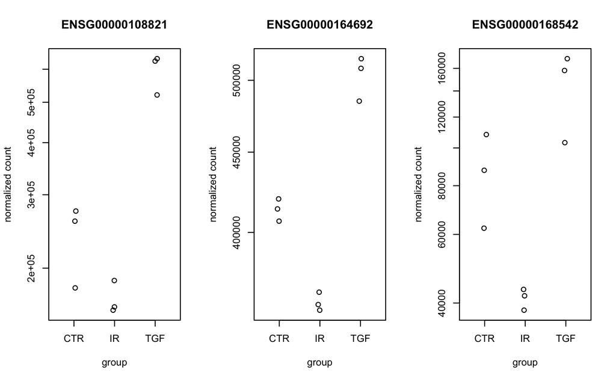

```r
plotCounts(dds, "ENSG00000168542", intgroup = "condition")
```

A ggplot2 version of the plot is a bit more complicated. Firstly, we can make use of the `returnData` argument to save the counts used in the plots and create three separate data frames.

```r
plot1 <- plotCounts(dds, "ENSG00000108821", intgroup = "condition",returnData = TRUE)
```

```
using 'avgTxLength' from assays(dds), correcting for library size
```

```r
plot2 <- plotCounts(dds, "ENSG00000164692", intgroup = "condition", returnData = TRUE)
```

```
using 'avgTxLength' from assays(dds), correcting for library size
```

```r
plot3 <- plotCounts(dds, "ENSG00000168542", intgroup = "condition", returnData = TRUE)
```

```
using 'avgTxLength' from assays(dds), correcting for library size
```

However, we will want to make separate plots for each gene and none of the data frames we have created contain information about what gene they relate to.

e.g.

```r
plot1
```

|  | count | condition |
| --- | --- | --- |
| 1_CTR_BC_2 | 274113.1 | CTR |
| 2_TGF_BC_4 | 627687.9 | TGF |
| 3_IR_BC_5 | 158579.0 | IR |
| 4_CTR_BC_6 | 259261.0 | CTR |
| 5_TGF_BC_7 | 520570.5 | TGF |
| 6_IR_BC_12 | 161449.6 | IR |
| 7_CTR_BC_13 | 179349.1 | CTR |
| 8_TGF_BC_14 | 636049.3 | TGF |
| 9_IR_BC_15 | 186794.0 | IR |

So we have to mutate each data frame to include a column with the gene name

```r
plot1 <- plotCounts(dds, "ENSG00000108821", intgroup = "condition",returnData = TRUE) %>%
  mutate(Gene = "COL1A1")
```

```
using 'avgTxLength' from assays(dds), correcting for library size
```

```r
plot2 <- plotCounts(dds, "ENSG00000164692", intgroup = "condition", returnData = TRUE) %>%
  mutate(Gene = "COL1A2")
```

```
using 'avgTxLength' from assays(dds), correcting for library size
```

```r
plot3 <- plotCounts(dds, "ENSG00000168542", intgroup = "condition", returnData = TRUE) %>%
  mutate(Gene = "COL3A1")
```

```
using 'avgTxLength' from assays(dds), correcting for library size
```

We can then create a combined data frame with the data from all genes

```r
bind_rows(plot1, plot2, plot3)
```

|  | count | condition | Gene |
| --- | --- | --- | --- |
| 1_CTR_BC_2...1 | 274113.14 | CTR | COL1A1 |
| 2_TGF_BC_4...2 | 627687.90 | TGF | COL1A1 |
| 3_IR_BC_5...3 | 158579.05 | IR | COL1A1 |
| 4_CTR_BC_6...4 | 259260.96 | CTR | COL1A1 |
| 5_TGF_BC_7...5 | 520570.50 | TGF | COL1A1 |
| 6_IR_BC_12...6 | 161449.59 | IR | COL1A1 |
| 7_CTR_BC_13...7 | 179349.06 | CTR | COL1A1 |
| 8_TGF_BC_14...8 | 636049.26 | TGF | COL1A1 |
| 9_IR_BC_15...9 | 186794.02 | IR | COL1A1 |
| 1_CTR_BC_2...10 | 420167.30 | CTR | COL1A2 |

[output cut: 17 more lines]

The `ggplot` function can be then be used for plotting. A `geom_jitter` geom adds some random noise to the x-axis and the `facet_wrap` function creates a separate panel for each gene.

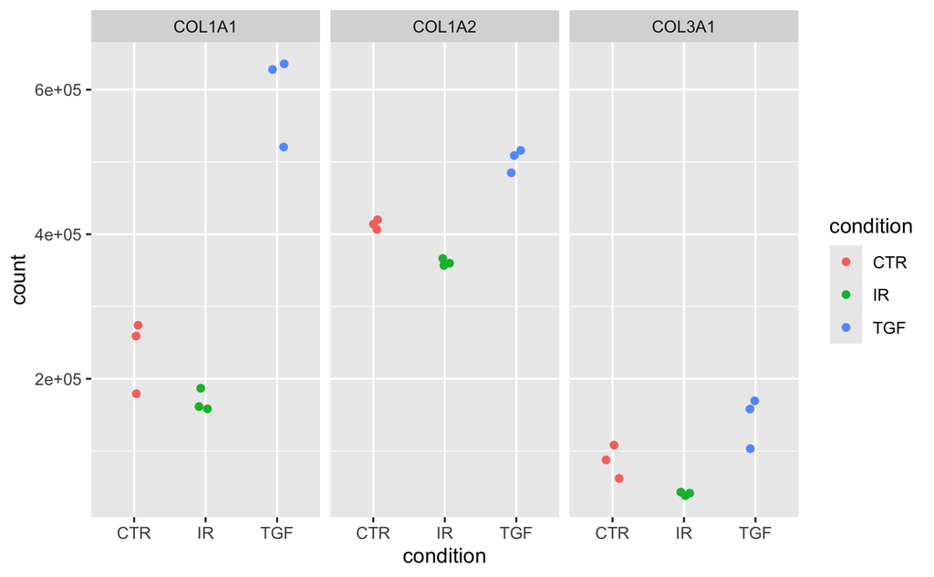

```r
library(ggplot2)
bind_rows(plot1, plot2, plot3) %>%
  ggplot(aes(x = condition, y = count, col = condition)) + geom_jitter(width=0.1) + facet_wrap(~Gene)
```

Since we are only looking at CTR and TGF groups, we could choose to exclude `IR` samples by filtering prior to plotting

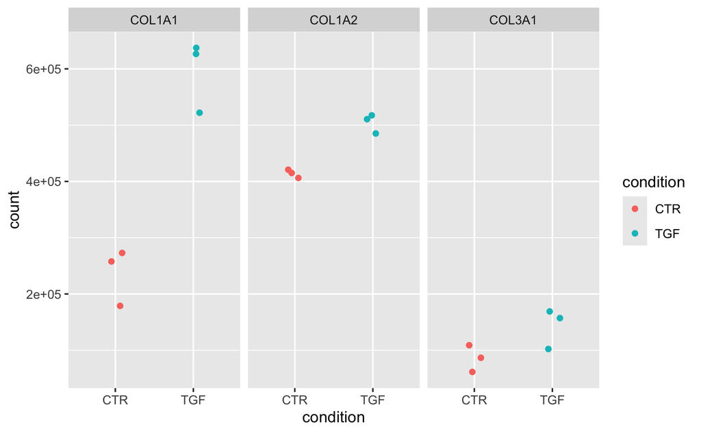

```r
library(ggplot2)
bind_rows(plot1, plot2, plot3) %>%
  filter(condition != "IR") %>%
  ggplot(aes(x = condition, y = count, col = condition)) + geom_jitter(width=0.1) + facet_wrap(~Gene)
```